# Simulacion de lazamiento de dos Dados

Frank Casanova

02/03/2021

## Con este codigo se representaremos la simulación del lanzamiento de dos dados

Se calculará la suma entre cada uno de los resultados y vamos a representarlo con varias cantidades de lanzamientos.

El código está desarrollado con `R` y `Python`.

En primero lugar cargamos la librería `reticulate` de `R` para poder usar Python en RStudio.

#### Código en `R`

```r
library(reticulate)
```

Ahora cargamos la librería `random` de `Python` para generar los números aleatorios que reprenstarán cada lanzamiento.

#### Código en `Python`

```python
import random
```

En Python inicializamos dos listas vacias `dado_1` y `dado_2` en las cuales guardaremos los resultados de cada lanzamiento.

Con el ciclo `for` haremos un loop en un rango de 0 a 20 , qeu en este caso representa 20 lanzamientos de los dos dados al mismo tiempo.

Usaremos tanto para la lista de `dado_1` como para `dado_2` la función `random.randint(1,6)` que nos generará un número entero aleatorio entre 1 y 6.

Con el método `append()` añadiremos cada resultado por cada loop que de el ciclo `for`.

```python
dado_1 = []
dado_2 = []

for lanzamiento in range(20):
    dado_1.append(random.randint(1,6))
    dado_2.append(random.randint(1,6))
```

Para hallar la suma de cada lanzamiento, inicializaremos una lista llamada `suma` en la cual con la ayuda de un ciclo `for` gaurdaremos la suma de cada lanzamiento.

```python
suma = []

for i in range(len(dado_1)):
    suma.append(dado_1[i]+dado_2[i])
```

Con `R` haremos un resumen de conteo, para eso primero tenemos que traer de python la lista `suma` y guardarla en un vector de `R` al cual llamaremos `suma_r`.

A continución con la funcion `table()` haremos un resumen de las veces que se repite cada suma y con la ayuda de la función `barplot()` graficaremos estos resultados.

#### Código en `R`

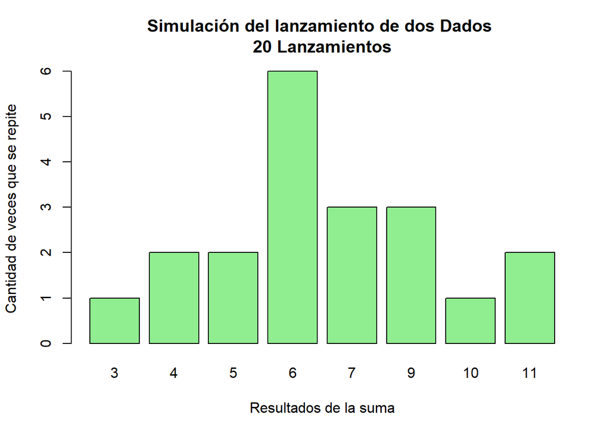

[figure not shown]

[figure not shown]

[figure not shown]

```r
suma_r = py$suma
barplot(table(suma_r), xlab = 'Resultados de la suma', ylab = 'Cantidad de veces que se repite', main = 'Simulación del lanzamiento de dos Dados \n20 Lanzamientos', col = 'lightgreen')
```

# Conclusiones